# Revision: Variance Quantification

Ramon Massoni-Badosa

3/3/2020

# 1 Introduction

In the following notebooks, we will perform the analysis requested by the reviewers to shed light into unclear parts of the article and increase the overall robustness of our study. Specifically, we will divide the work into 4 notebooks, corresponding to the major actionable concerns of reviewer #2. On the contrary, the comments by reviewer #1 were mainly related to the introduction and discussion of the paper, so we focused on rephrasing those parts to convey our points more effectively.

The objective of this notebook is to quantify and compare the variance introduced by sampling time more thoroughly. In our first version, we provided clear evidence that sampling time is a source of technical artifacts in scRNA-seq. However, the magnitude of this effect is still vague, specially in comparison with other drivers of variance.

# 2 Pre-processing

## 2.1 Package loading

```r
library(scater)
library(Seurat)
library(ggpubr)
library(purrr)
library(kBET)
library(viridis)
library(pheatmap)
library(propr)
library(cowplot)
library(tidyverse)
```

## 2.2 Source script with function definitions

```r
source("bin/utils.R")
```

## 2.3 Load data

```r
# PBMC
pbmc <- readRDS("../1-PBMC/results/R_objects/10X_pbmc_Seurat_clustered.RDS")
pbmc <- subset(pbmc, subset = condition %in% c("0h", "2h", "8h", "24h_RT", "48h_RT"))
pbmc$time <- factor(pbmc$condition, levels = c("0h", "2h", "8h", "24h_RT", "48h_RT"))
levels(pbmc$time) <-  c("0h", "2h", "8h", "24h", "48h")
Idents(pbmc) <- "cell_type"

# CLL
cll <- readRDS("../2-CLL/results/R_objects/cll_seurat_annotated.rds")
cll <- subset(cll, temperature == "RT")
```

# 3 Drivers of cell-cell variability

Herein, we will introduce *ρ* as a universal measure of cell similarity. In a benchmark of 17 cell-cell association metrics, [Skinnider *et al.*](https://www.nature.com/articles/s41592-019-0372-4) showed that measures of proportionality (ρ and ɸ) displayed the highest accuracy (considerably better than Pearson correlation). Thus, we will downsample T-cells and B-cells from the PBMC dataset and leukemic cells from the three patients in the CLL dataset and compute all cell-cell pairwise ρ. To achieve it, we will use the `perb()` function from the [propr](https://www.nature.com/articles/s41598-017-16520-0) package:

```r
pbmc_l <- SplitObject(pbmc, split.by = "cell_type")
purrr:::map(pbmc_l, function(seurat) table(seurat$time))
```

```
## $Monocyte
##
##  0h  2h  8h 24h 48h
## 511  24 159 292  48
##
## $T
##
##   0h   2h   8h  24h  48h
## 3057  318 1455  956  518
##
## $NK
##
##   0h   2h   8h  24h  48h
## 1104  107  438  281  111
##
## $B
##
##  0h  2h  8h 24h 48h
## 244  19  93  83  20
```

```r
sizes <- c(50, 50, 50, 50)
set.seed(1)
pbmc_down_l <- purrr::map2(pbmc_l, sizes, function(seurat, x) {
  print(seurat)
  sizes2 <- ifelse(table(seurat$time) < x, table(seurat$time), x)
  seurat_split <- SplitObject(seurat, split.by = "time")
  seurat_split <- seurat_split[names(sizes2)]
  cells_selected <- purrr::map2(seurat_split, sizes2, function(seurat2, x2) {
    sample(colnames(seurat2), size = x2, replace = FALSE)
  })
  cells_selected <- unlist(cells_selected)
  names(cells_selected) <- NULL
  seurat_out <- SubsetData(seurat, cells = cells_selected)
  seurat_out
})
```

```
## An object of class Seurat
## 9803 features across 1034 samples within 1 assay
## Active assay: RNA (9803 features)
##  6 dimensional reductions calculated: PCA, TSNE, UMAP, pca, tsne, umap
## An object of class Seurat
## 9803 features across 6304 samples within 1 assay
## Active assay: RNA (9803 features)
##  6 dimensional reductions calculated: PCA, TSNE, UMAP, pca, tsne, umap
## An object of class Seurat
## 9803 features across 2041 samples within 1 assay
## Active assay: RNA (9803 features)
##  6 dimensional reductions calculated: PCA, TSNE, UMAP, pca, tsne, umap
## An object of class Seurat
## 9803 features across 459 samples within 1 assay
## Active assay: RNA (9803 features)
##  6 dimensional reductions calculated: PCA, TSNE, UMAP, pca, tsne, umap
```

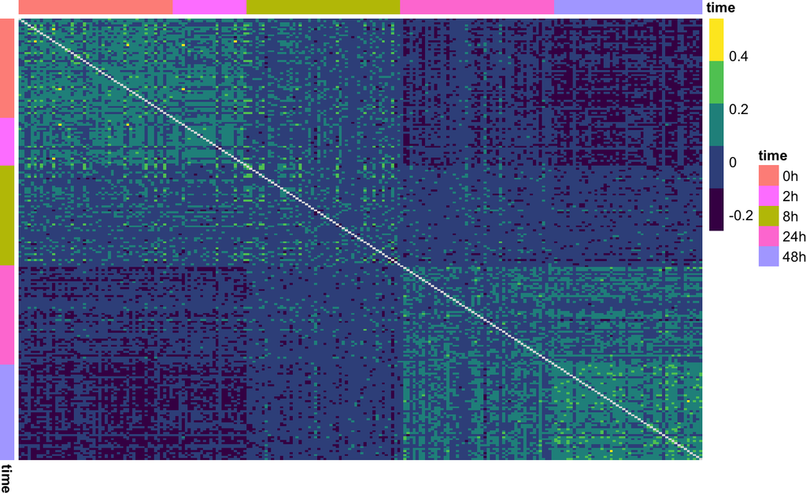

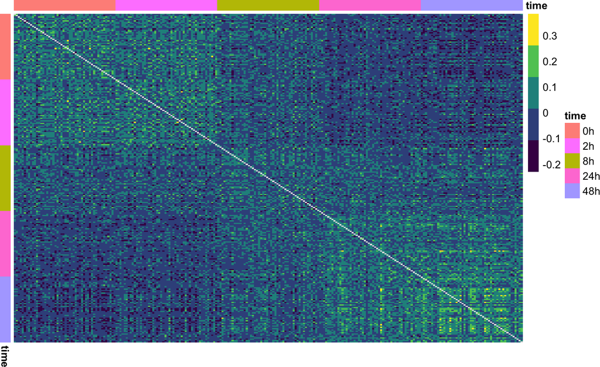

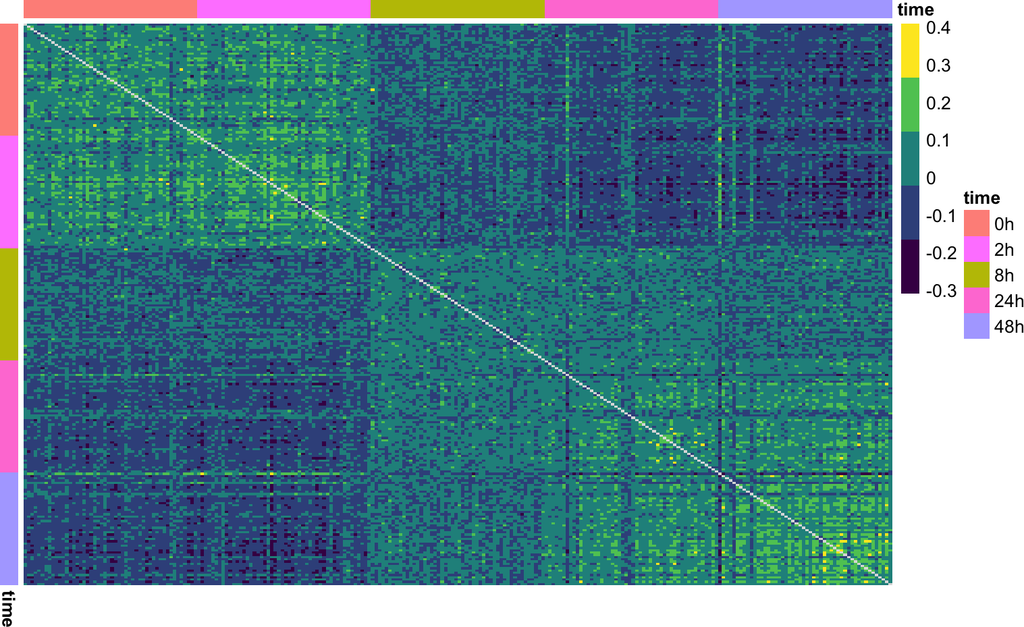

```r
cells_selected <- purrr::map(pbmc_down_l, colnames)
cells_selected <- unlist(cells_selected)
names(cells_selected) <- NULL
pbmc_down <- SubsetData(pbmc, cells = cells_selected)
cols <- viridis(5)
heatmaps_cell_type <- purrr::map(pbmc_down_l, function(seurat) {
  mat <- as.matrix(seurat[["RNA"]]@data)
  mat <- mat[seurat[["RNA"]]@var.features, ]
  corr_mat <- propr::perb(mat, select = colnames(mat))@matrix
  diag(corr_mat) <- NA
  annotation_row <- data.frame(time = seurat$time)
  rownames(annotation_row) <- names(seurat$time)
  annotation_col <- annotation_row
  pheatmap(
    corr_mat,
    color = cols,
    cluster_rows = FALSE,
    cluster_cols = FALSE,
    show_rownames = FALSE,
    show_colnames = FALSE,
    annotation_row = annotation_row,
    annotation_col = annotation_col
  )
})
```

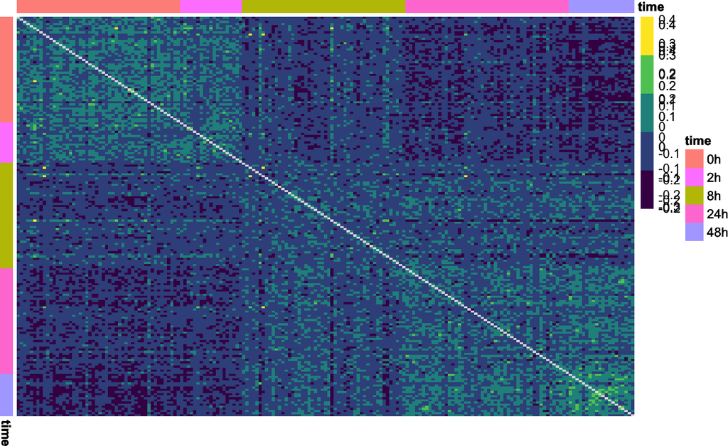

```r
heatmaps_cell_type
```

```r
# T vs B
pbmc_down_l2 <- pbmc_down_l[c("T", "B")]
pbmc_down_l2 <- purrr::map(pbmc_down_l2, pre_process_seurat)
cells_selected2 <- purrr::map(pbmc_down_l2, colnames)
cells_selected2 <- unlist(cells_selected2)
names(cells_selected2) <- NULL
pbmc_down2 <- SubsetData(pbmc, cells = cells_selected2)
mat <- as.matrix(pbmc_down2[["RNA"]]@data)
features <- purrr::map(pbmc_down_l2, ~ .x[["RNA"]]@var.features)
features <- unlist(features)
names(features) <- NULL
features <- c(features, pbmc_down2[["RNA"]]@var.features)
features <- unique(features)
mat <- mat[features, ]
corr_mat <- propr::perb(mat, select = colnames(mat))@matrix
diag(corr_mat) <- NA
annotation_row <- data.frame(type = pbmc_down2$cell_type, time = pbmc_down2$time)
annotation_row$type <- droplevels(annotation_row$type)
levels(annotation_row$type) <- c("T-cell", "B-cell")
rownames(annotation_row) <- names(pbmc_down2$time)
colorRampPalette(c("blue", "white", "red"))(10)
```

```
##  [1] "#0000FF" "#3838FF" "#7171FF" "#AAAAFF" "#E2E2FF" "#FFE2E2" "#FFAAAA" "#FF7171" "#FF3838" "#FF0000"
```

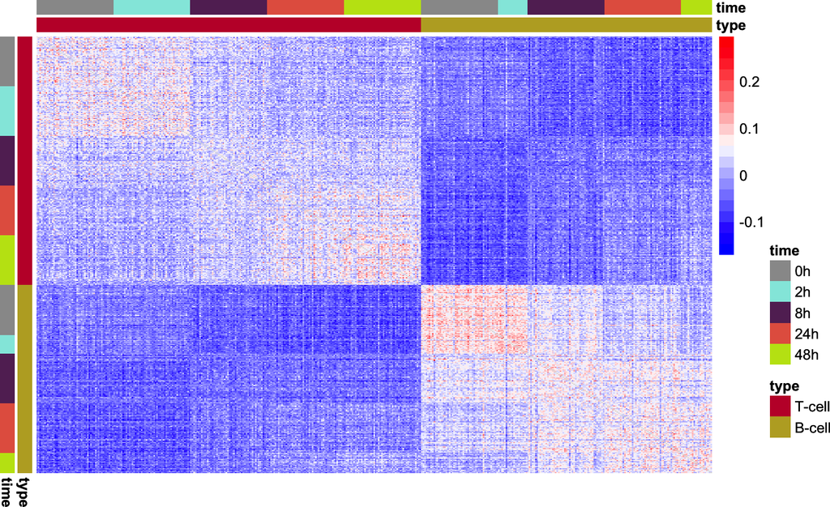

```r
annotation_col <- annotation_row
ann_colors <- list(
  type = c("T-cell" = "#c20a35", "B-cell" = "#bbaa2a"),
  time = c("0h" = "#999999", "2h" = "#92e8df", "8h" = "#632c63", "24h" = "#e4624e", "48h" = "#c0e212")
)
heatmap_pbmc <- pheatmap(
  corr_mat,
  color = colorRampPalette(c("blue", "white", "red"))(20),
  cluster_rows = FALSE,
  cluster_cols = FALSE,
  show_rownames = FALSE,
  show_colnames = FALSE,
  annotation_row = annotation_row,
  annotation_col = annotation_col,
  annotation_colors = ann_colors,
  legend = TRUE
)
heatmap_pbmc
```

```r
# saveRDS(heatmap_pbmc, "results/R_objects/heatmap_pbmc_cell2cell_association.rds")

# CLL
Idents(cll) <- "cell_type"
cll_sub <- subset(cll, idents = c("CLL 1220", "CLL 1472", "CLL 1892"))
cll_sub$cell_type <- droplevels(cll_sub$cell_type)
cll_l <- SplitObject(cll_sub, split.by = "cell_type")
size <- 50
set.seed(1)
cll_down_l <- purrr::map(cll_l, function(seurat) {
  print(seurat)
  sizes2 <- ifelse(table(seurat$time) < size, table(seurat$time), size)
  seurat_split <- SplitObject(seurat, split.by = "time")
  seurat_split <- seurat_split[names(sizes2)]
  cells_selected <- purrr::map2(seurat_split, sizes2, function(seurat2, x2) {
    sample(colnames(seurat2), size = x2, replace = FALSE)
  })
  cells_selected <- unlist(cells_selected)
  names(cells_selected) <- NULL
  seurat_out <- SubsetData(seurat, cells = cells_selected)
  seurat_out
})
```

```
## An object of class Seurat
## 15710 features across 5603 samples within 1 assay
## Active assay: RNA (15710 features)
##  3 dimensional reductions calculated: pca, tsne, umap
## An object of class Seurat
## 15710 features across 7612 samples within 1 assay
## Active assay: RNA (15710 features)
##  3 dimensional reductions calculated: pca, tsne, umap
## An object of class Seurat
## 15710 features across 7670 samples within 1 assay
## Active assay: RNA (15710 features)
##  3 dimensional reductions calculated: pca, tsne, umap
```

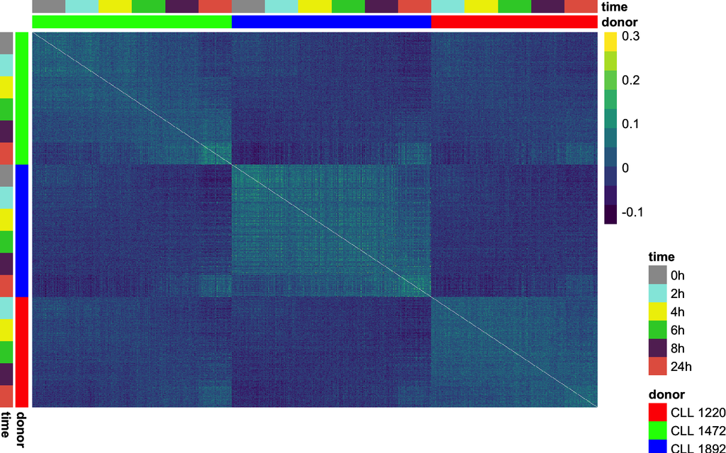

```r
cells_selected <- purrr::map(cll_down_l, colnames)
cells_selected <- unlist(cells_selected)
names(cells_selected) <- NULL
cll_down <- SubsetData(cll_sub, cells = cells_selected)
mat <- as.matrix(cll_down[["RNA"]]@data)
cll_down_l <- purrr::map(cll_down_l, pre_process_seurat)
features_cll <- purrr::map(cll_down_l, ~ .x[["RNA"]]@var.features)
features_cll <- unlist(features_cll)
names(features_cll) <- NULL
features_cll <- c(features_cll, cll_down[["RNA"]]@var.features)
features_cll <- unique(features_cll)
mat <- mat[features_cll, ]
corr_mat <- propr::perb(mat, select = colnames(mat))@matrix
diag(corr_mat) <- NA
annotation_row <- data.frame(donor = cll_down$cell_type, time = cll_down$time)
rownames(annotation_row) <- names(cll_down$time)
annotation_col <- annotation_row
ann_colors <- list(
  donor = c("CLL 1220" = "red", "CLL 1472" = "green", "CLL 1892" = "blue"),
  time = c("0h" = "#999999", "2h" = "#92e8df", "4h" = "yellow2", "6h" = "limegreen", "8h" = "#632c63", "24h" = "#e4624e")
)
heatmap_cll <- pheatmap(
  corr_mat,
  color = viridis(10),
  cluster_rows = FALSE,
  cluster_cols = FALSE,
  show_rownames = FALSE,
  show_colnames = FALSE,
  annotation_row = annotation_row,
  annotation_col = annotation_col,
  annotation_colors = ann_colors,
  legend = TRUE
)
heatmap_cll
```

```r
# pdf(file = "results/plots/heatmap_dist_mat_cll.pdf", width = 5, height = 5, "cm")
# heatmap_cll
# dev.off()
# saveRDS(heatmap_cll, "results/R_objects/heatmap_cll_cell2cell_association.rds")
```

As we can see, and consistent with our initial findings, cell type and sampling time are first and second largest sources of variance in the PBMC dataset, respectively. On the other hand, patient and sampling time are the greatest drivers of variance in the CLL dataset, which is consistent with the [large interpatient variability observed in CLL](https://genome.cshlp.org/content/24/2/212.abstract).

# 4 Regression analysis

As a complementary analysis, we will regress the gene expression values of 5,282 genes on one of four explanatory variables (cell type, time, donor and batch), and extract a distribution of r2 values for each variable:

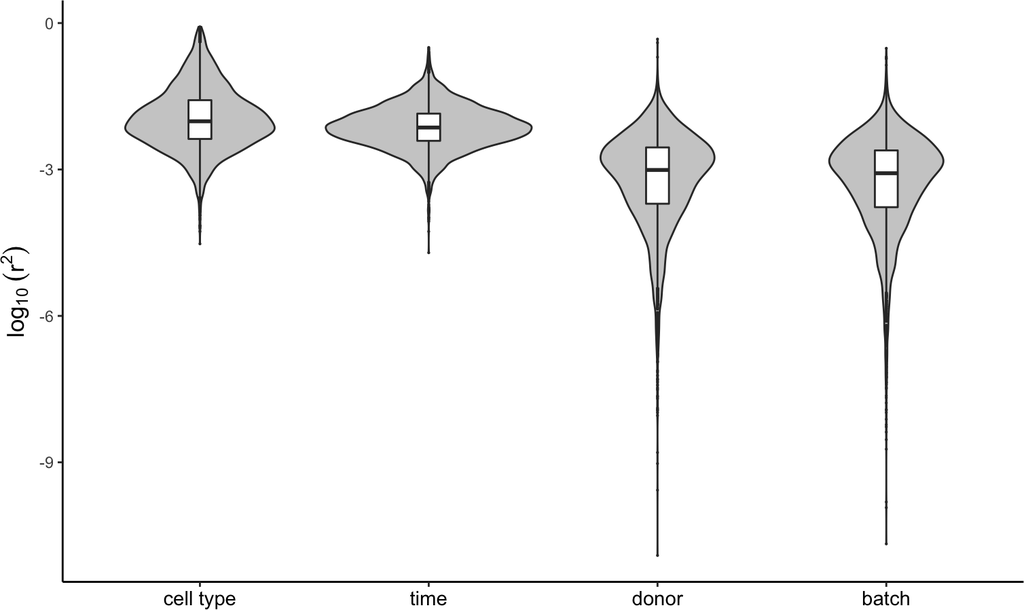

```r
# Simple regression
features_cell_types <- purrr::map(pbmc_down_l, function(seurat) {
  seurat <- FindVariableFeatures(seurat)
  seurat[["RNA"]]@var.features
})
pbmc_down <- FindVariableFeatures(pbmc_down)
features_cell_types[["merged"]] <- pbmc_down[["RNA"]]@var.features
features <- Reduce(union, features_cell_types)
metadata <- pbmc_down@meta.data[, c("cell_type", "time", "donor", "batch")]
metadata$time <- factor(metadata$time, levels = levels(metadata$time), ordered = TRUE)
metadata$donor <- factor(metadata$donor, levels = c("male", "female"))
metadata$batch <- factor(metadata$batch, levels = c("JULIA_03", "JULIA_04"))
features_lm_l <- purrr::map(features, function(gene) {
  df <- cbind(metadata, pbmc_down[["RNA"]]@data[gene, ])
  names(df) <- c(names(metadata), "gene")
  r2_cell_type <- summary(lm(gene ~ cell_type, data = df))$r.squared
  r2_time <- summary(lm(gene ~ time, data = df))$r.squared
  r2_donor <- summary(lm(gene ~ donor, data = df))$r.squared
  r2_batch <- summary(lm(gene ~ batch, data = df))$r.squared
  out <- data.frame(
    r2 = c(r2_cell_type, r2_time, r2_donor, r2_batch),
    explanatory_variable = c("cell_type", "time", "donor", "batch"),
    gene = rep(gene, 4)
  )
  out
})
names(features_lm_l) <- features
features_lm_df <- bind_rows(features_lm_l)
features_lm_df$explanatory_variable <- factor(
  features_lm_df$explanatory_variable,
  levels = c("cell_type", "time", "donor", "batch")
)
levels(features_lm_df$explanatory_variable) <- c("cell type", "time", "donor", "batch")
features_lm_gg <- features_lm_df %>%
  ggplot(aes(explanatory_variable, log10(r2))) +
    geom_violin(fill = "darkgrey", alpha = 0.6) +
    geom_boxplot(width = 0.1, fill = "white", outlier.size = 0.1) +
    labs(x = "", y = expression(log[10]~(r^{2}))) +
    theme_classic() +
    theme(legend.position = "none",
          axis.title.y = element_text(size = 13),
          axis.text.x = element_text(size = 11, color = "black"))
# ggsave(
#   plot = features_lm_gg,
#   filename = "results/plots/boxplot_r2_all.pdf",
#   height = 6,
#   width = 9,
#   units = "cm"
# )
features_lm_gg
```

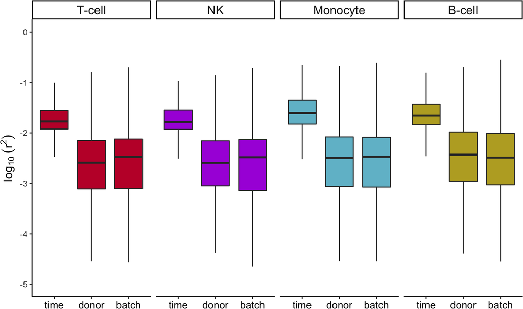

```r
# Stratified by cell type
metadata_dfs <- purrr::map(pbmc_down_l, function(seurat) {
  metadata <- seurat@meta.data[, c("time", "donor", "batch")]
  metadata$time <- factor(metadata$time, levels = levels(metadata$time), ordered = TRUE)
  metadata$donor <- factor(metadata$donor, levels = c("male", "female"))
  metadata$batch <- factor(metadata$batch, levels = c("JULIA_03", "JULIA_04"))
  metadata
})
features_lm_by_ct <- purrr::map2(pbmc_down_l, metadata_dfs, function(seurat, metadata) {
  features_lm_l <- purrr::map(features, function(gene) {
    df <- cbind(metadata, seurat[["RNA"]]@data[gene, ])
    names(df) <- c(names(metadata), "gene")
    r2_time <- summary(lm(gene ~ time, data = df))$r.squared
    r2_donor <- summary(lm(gene ~ donor, data = df))$r.squared
    r2_batch <- summary(lm(gene ~ batch, data = df))$r.squared
    out <- data.frame(
      r2 = c(r2_time, r2_donor, r2_batch),
      explanatory_variable = c("time", "donor", "batch"),
      gene = rep(gene, 3)
    )
    out
  })
  names(features_lm_l) <- features
  features_lm_df <- bind_rows(features_lm_l)
  features_lm_df$explanatory_variable <- factor(
    features_lm_df$explanatory_variable,
    levels = c("time", "donor", "batch")
  )
  features_lm_df
})
features_lm_by_ct <- bind_rows(features_lm_by_ct, .id = "cell_type")
palette2 <- c("#c20a35", "#aa2edc", "#71bdd0", "#bbaa2a")
cell_types <- c("T", "NK", "Monocyte", "B")
features_lm_by_ct$cell_type <- factor(features_lm_by_ct$cell_type, levels = cell_types)
levels(features_lm_by_ct$cell_type) <- c("T-cell", "NK", "Monocyte", "B-cell")
features_gg_by_ct <- features_lm_by_ct %>%
    ggplot(aes(explanatory_variable, log10(r2), fill = cell_type)) +
    # geom_violin() +
    geom_boxplot(outlier.shape = NA) +
    facet_grid(.~cell_type) +
    labs(x = "", y = expression(log[10]~(r^{2}))) +
    scale_y_continuous(limits = c(-5, 0 )) +
    scale_fill_manual(values = palette2) +
    theme_classic() +
    theme(strip.text = element_text(size = 13),
          legend.position = "none",
          axis.title.y = element_text(size = 13),
          axis.text.x = element_text(size = 11, color = "black"))
features_gg_by_ct
```

```r
# ggsave(
#   plot = features_gg_by_ct,
#   filename = "results/plots/boxplot_r2_by_cell_type.pdf",
#   width = 19,
#   height = 6,
#   units = "cm"
# )
# p <- readRDS("../1-PBMC/results/R_objects/pct_variance_explained_pc1.rds")
# ggsave(
#   plot = p,
#   filename = "results/plots/pct_variance_explained_pc1.pdf",
#   width = 19,
#   height = 6,
#   units = "cm"
# )
```

# 5 Arrange figure

```r
# fig_row1 <- p
# fig_row2 <- plot_grid(heatmap_pbmc[[4]], NULL, heatmap_cll[[4]], ncol = 3,
#                       rel_widths = c(1, 0.05, 1))
# fig_row3 <- features_gg_by_ct
# fig <- plot_grid(fig_row1, NULL, fig_row2, NULL, fig_row3, nrow = 5,
#                  rel_widths = c(1, 0.05, 1, 0.05, 1))
# fig
# ggsave(plot = fig, filename = "../doc/figures/R/supp_variance.pdf", width = 18.5, height = 22.5, units = "cm")
```